# ShinyDataSHIELD User’s Guide

## 3.1 Data entry

[output not shown]

The first step to any analysis is to load the required tables or resources to the study server(s). To do so, the user has to provide the server URL and the login credentials. This will allow the application to connect to the OPAL server and retrieve all the projects and resources / tables from them. Afterwards, the user can select the desired resources / tables and load them to the study servers.

It is very important to understand the difference between a server (OPAL server) and a study server (R instances running inside an OPAL server), a study server can be visualized as an R session that has some tables and resources loaded. For that reason we can have multiple study servers on a single OPAL server, which is indeed needed when performing pooled studies.

To properly explain how to load the desired study servers for multiple types of analysis, let’s do a guided tour of the interface.

Since Opal 4.2 there is a new concept introduced called `profiles` which correspond to different R servers ([rockr](https://rockdoc.obiba.org/en/latest/)). The user can choose which profile to use for each study server (more info here).

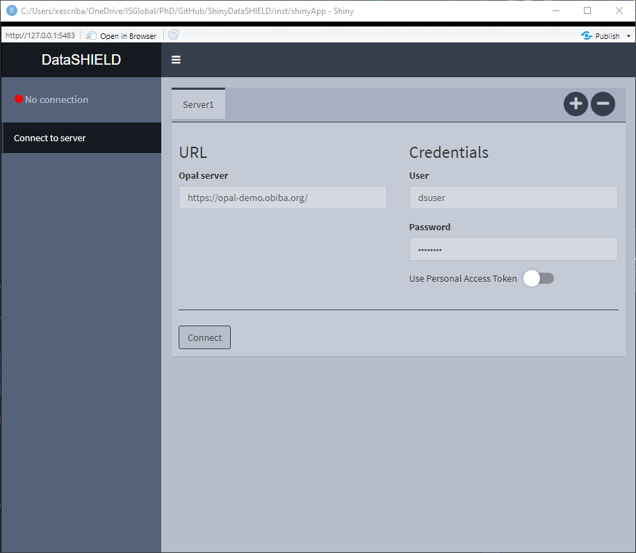

Figure 3.1: Connect to server, initial state

On Figure 3.1 the initial state of the *Connect to server* tab is shown, here we can see some credentials are already inputted, which correspond to a demo server. There is the option of performing a login to the server via traditional user/pass or using personal access token [PAT].

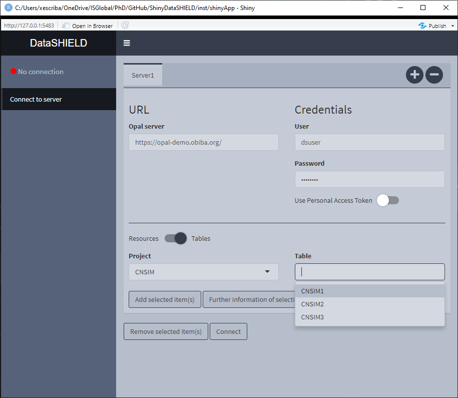

Figure 3.2: Connect to server, selecting tables and resources

Once connected to the server, the interface is actualized showing the available projects that contain tables inside. To show the projects that contain resources, just click on the *Table* toggle. An example is illustrated on Figure 3.2.

If we want to get further information from a table(s) or resource(s), select them and click on the *Further information of selection*, this will open the OPAL UI on a browser and will display the associated page for the selected items. If more than one item is selected, a page for each one will be opened. An example of this functionality is shown on the Figure 3.3 where a table was selected to retrieve further information.

[figure not shown]

Figure 3.3: OPAL UI with information from a table

Knowing which items are of our interest, we can add them to be loaded on the study servers, to do that select the items and click *Add selected item(s)*. A new table will appear underneath showing everything selected, illustrated on Figure 3.4. On this table all the elements from all the servers will be added to have the general picture of what will be available on the study servers.

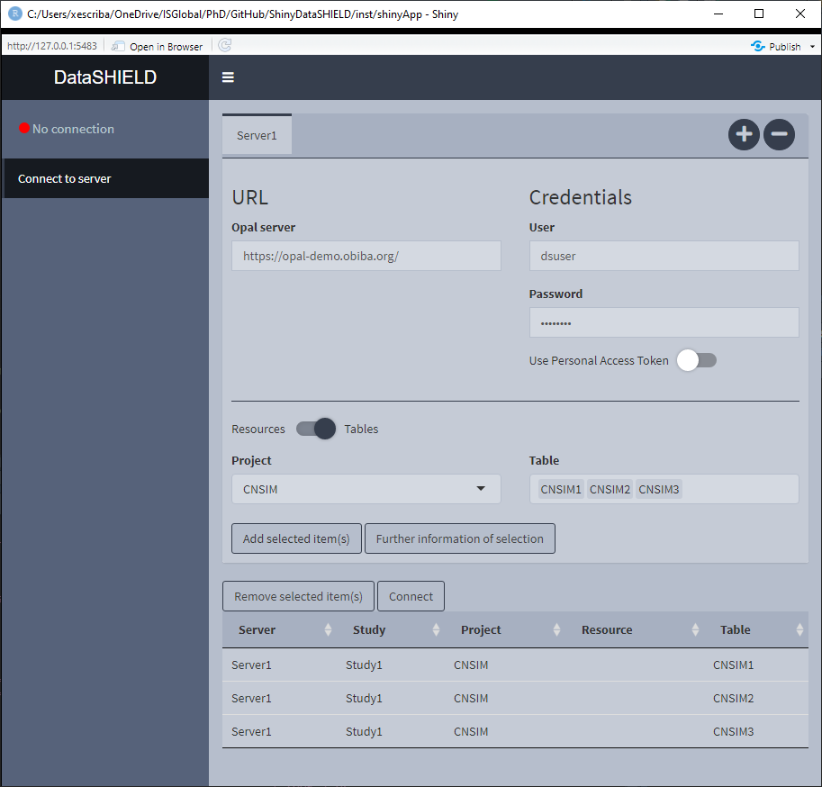

Figure 3.4: Connect to server, selected items

Reached this point, let’s see different use cases and how we have to configure the application for them.

### 3.1.1 Single resource / table approach

Not much to say about this, just select it and click the *Connect* button.

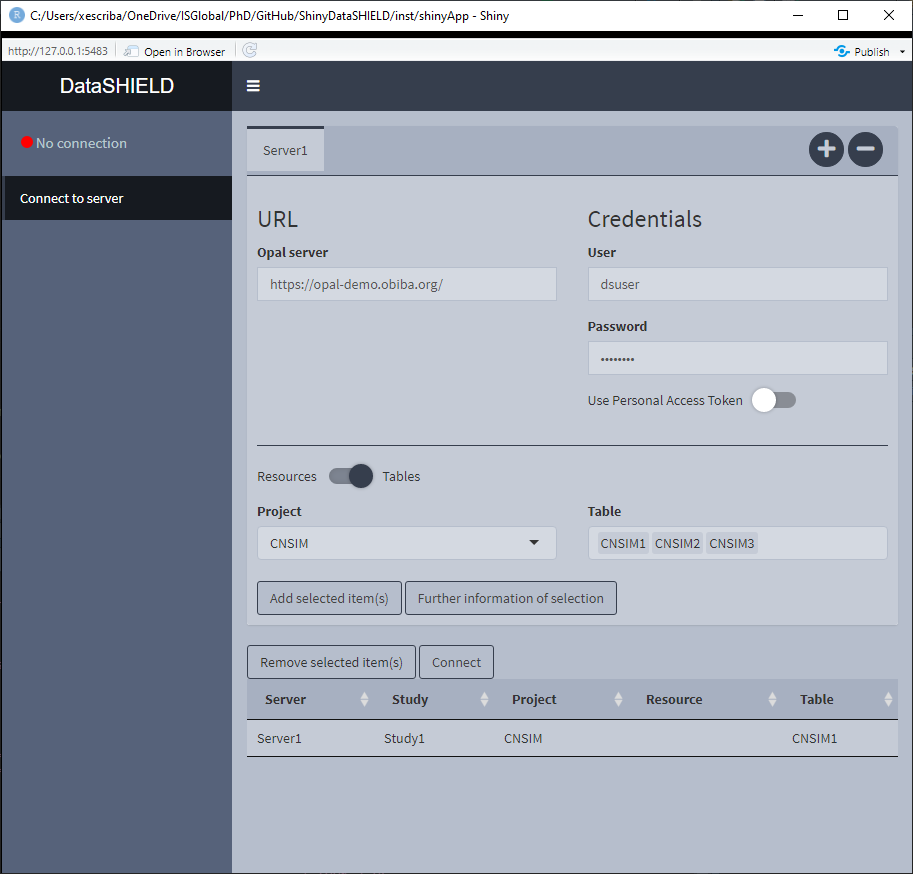

Figure 3.5: Connect to server. Single resource / table approach

### 3.1.2 Multiple resource study

Some studies require to put more than one resource on a single study server, this is the case of using VCF files to perform a GWAS; they require two resources, the VCF resource and the covariates resource (which is a resource that holds a plain table). For this use case, the user has to select the multiple resources from the dropdown inputs, add them to a single study and connect to it. Two important things must be said for this use case, 1) By default the tables/resources from one server are added to the same study server; 2) to have tables/resources on the same study server, they have to be from the same server, this translates to: we can’t put a table from server X and a resource from server Y on the same study server.

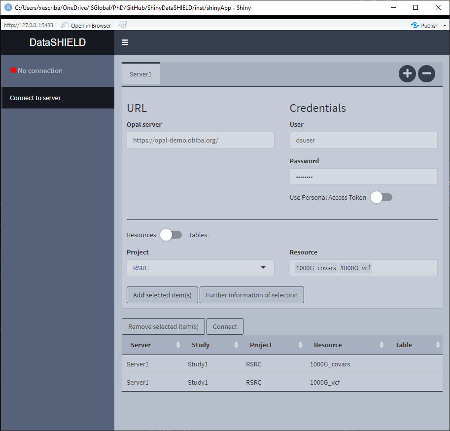

### 3.1.3 Pooled data from the same server

It is not uncommon that the same OPAL server has multiple tables that we wish to analyze using a pooled approach. To perform this kind of analysis we have to select all the tables (they have to consistent column-wise to be pooled). The important thing to take into account is that the tables need to be on different study servers in order to be analyzed using a pooled approach, in order to achieve that the user has to double click on the cells in order to edit them (Figure 3.7). There are a couple of rules regarding the naming of the study servers, 1) User inputted names can’t be of the format `StudyX` (where X is a number), and 2) Similarly to what has been stated before, items from different servers can’t be on the same study server.

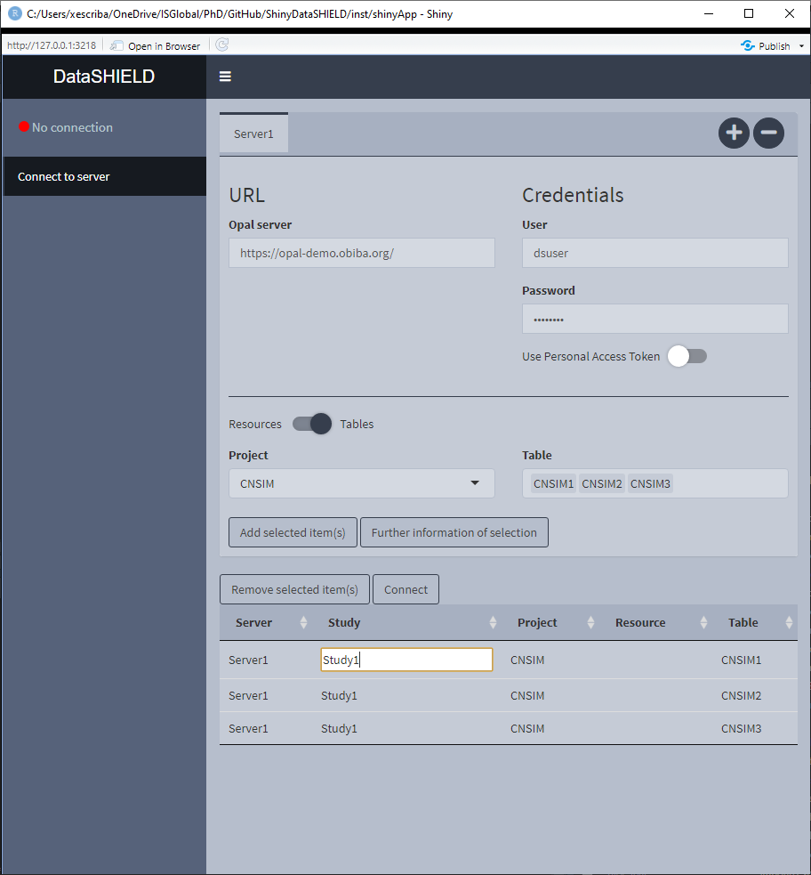

Figure 3.7: Connect to server. Study server edit

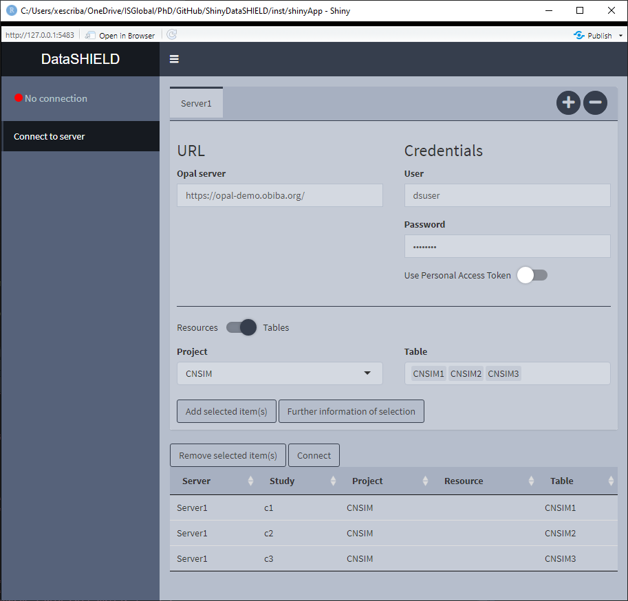

Figure 3.8: Connect to server. Pooled data from the same server approach

### 3.1.4 Pooled data from different servers

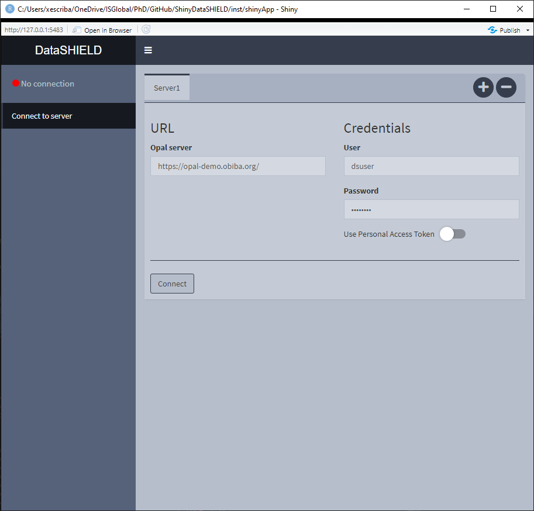

Figure 3.9: Connect to server. New server

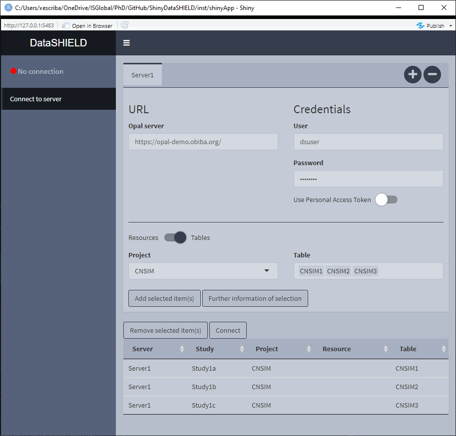

### 3.1.5 Study server profiles

Extracted from the [official documentation](https://opaldoc.obiba.org/en/latest/admin/rserver.html): “A DataSHIELD profile is a R server profile combined with a DataSHIELD configuration (allowed functions, options and permissions). DataSHIELD users can then decide in which environment their analysis are to be performed, for a better reproducible science.” On the opal-demo site, there is a different array of profiles, illustrated on the Figure 3.11.

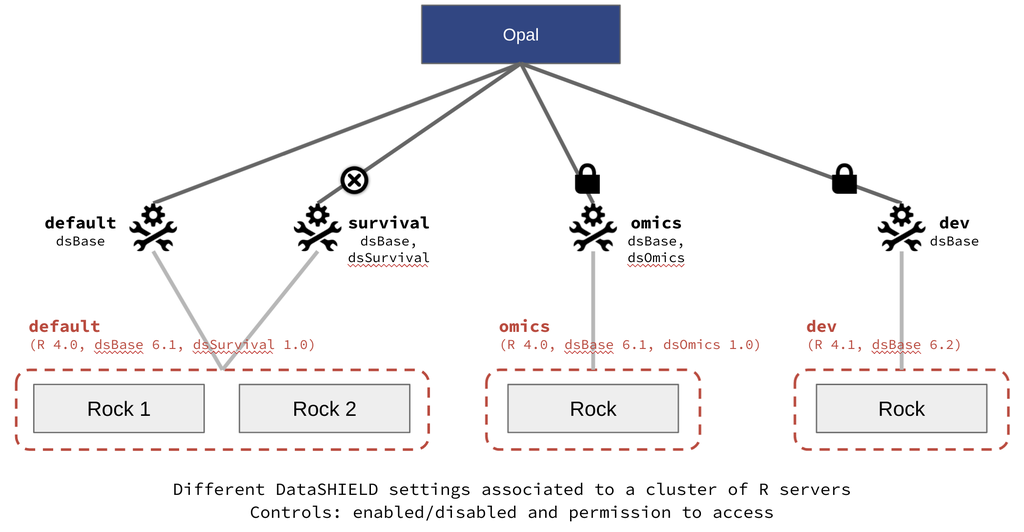

Figure 3.11: Opal demo profiles. Extracted from https://opaldoc.obiba.org/

In ShinyDataSHIELD, there is the option of assigning the required profile to each study server, there is only one requirement to be taken into account: A study server can only have one distinct profile. So the configuration table of Figure 3.12 is valid, and the configuration table of Figure 3.13 will yield a connection error (Figure 3.14).

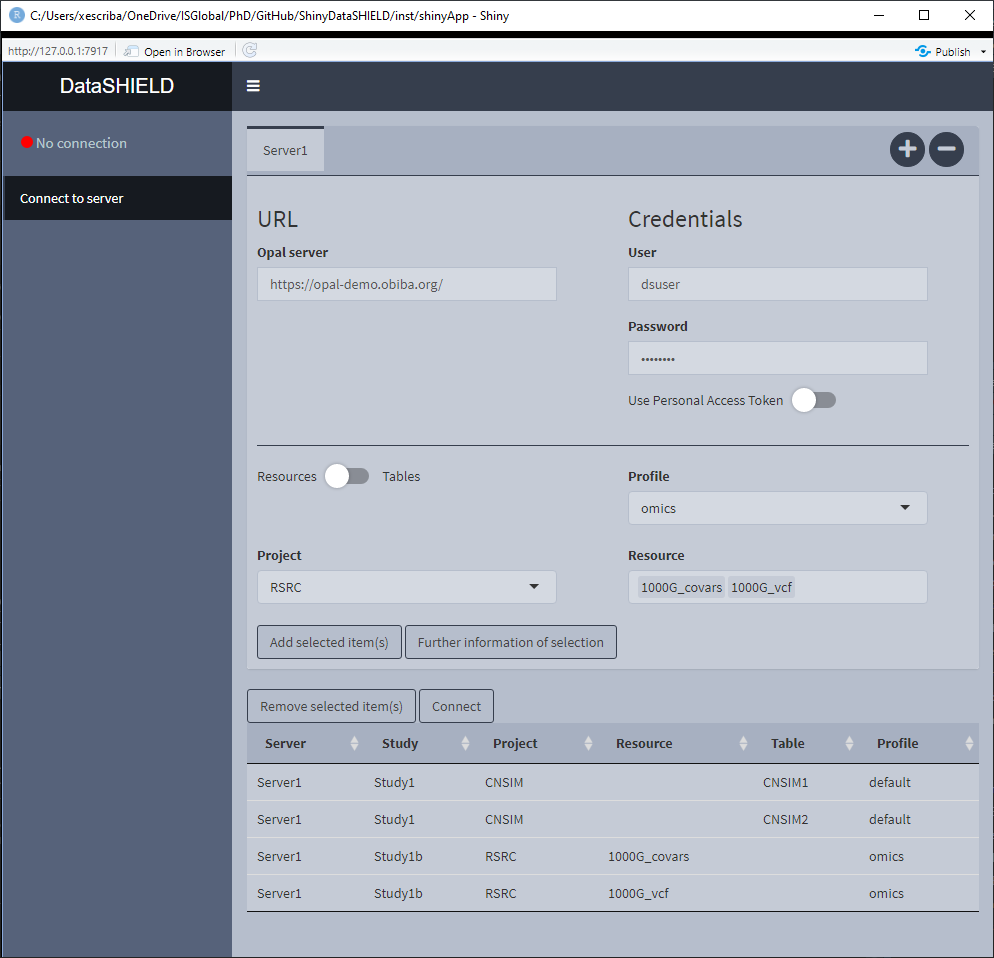

Figure 3.12: Correct profiles configuration

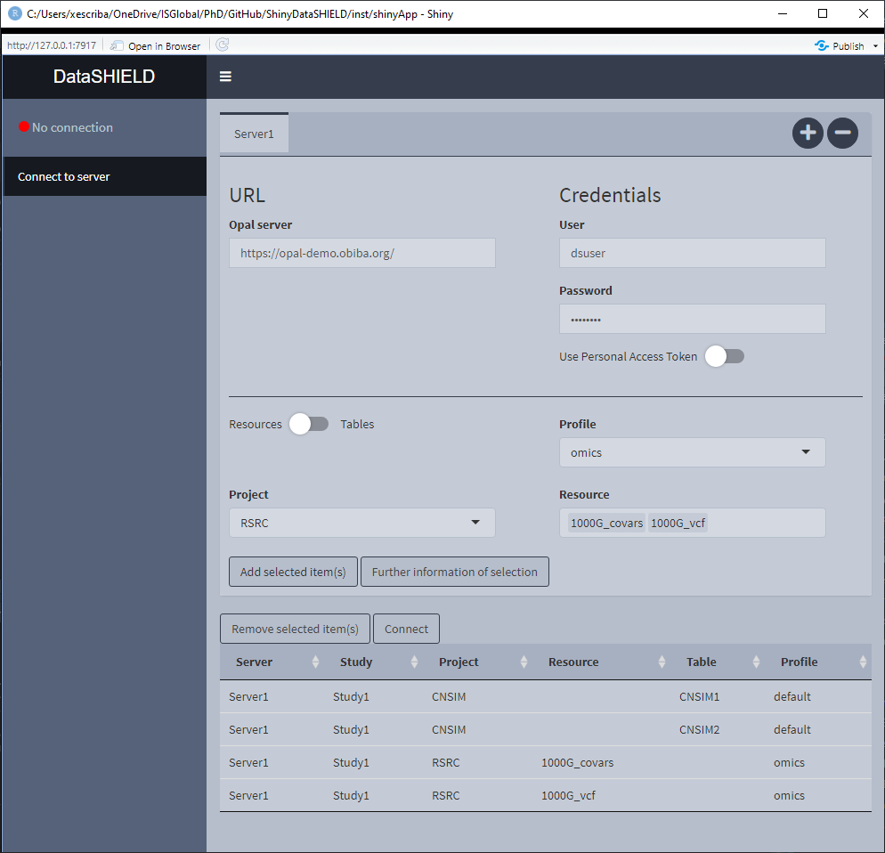

Figure 3.13: Incorrect profiles configuration

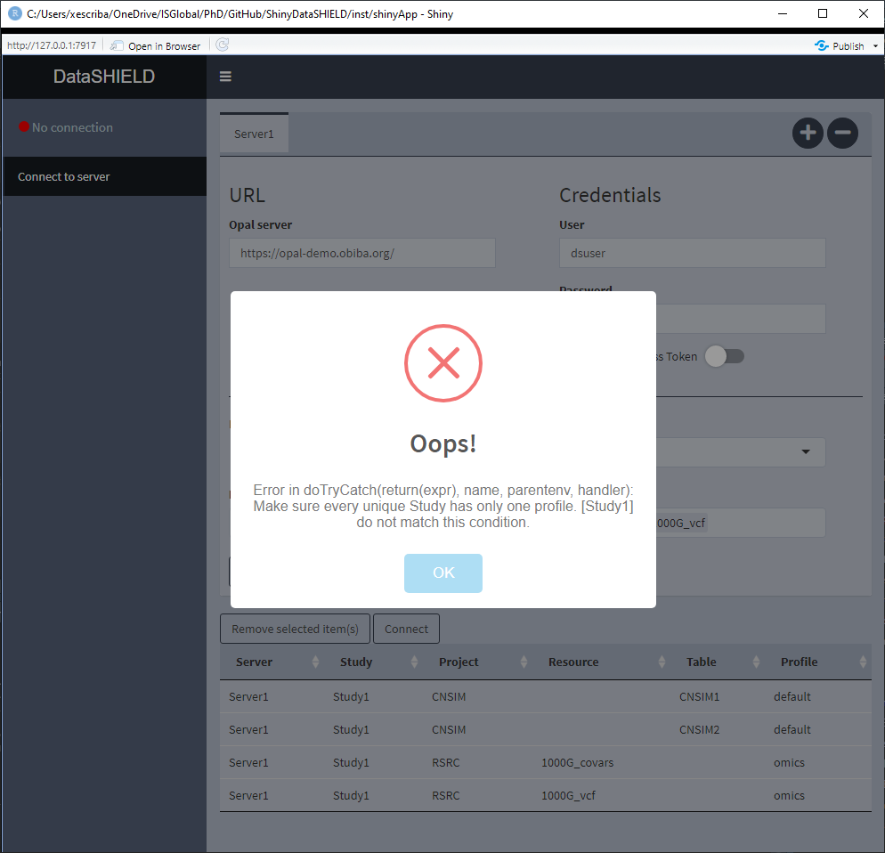

Figure 3.14: Incorrect profiles configuration error message

## 3.2 Table column types

| ⚠️ TABLES USED TO DEMO THIS SECTION |
| --- |
| From https://opal-demo.obiba.org/ : |
| STUDY TABLE PROFILE Study1a CNSIM.CNSIM1 default Study1b CNSIM.CNSIM2 default Study1c CNSIM.CNSIM3 default |

The table column types functionality is available for tables as well as the following resource types:

- SQL tables
- Tidy data files (tables): `*.csv`, `*.tsv`, etc

All of the above options will be shown on the table that shows the available tables to use on this module. As stated on the use cases, to perform a pooled analysis the tables have to be on different study servers. Column integrity is checked before allowing the user the access to the other tabs.

The function of this module is to get information about the class of each column of a table.

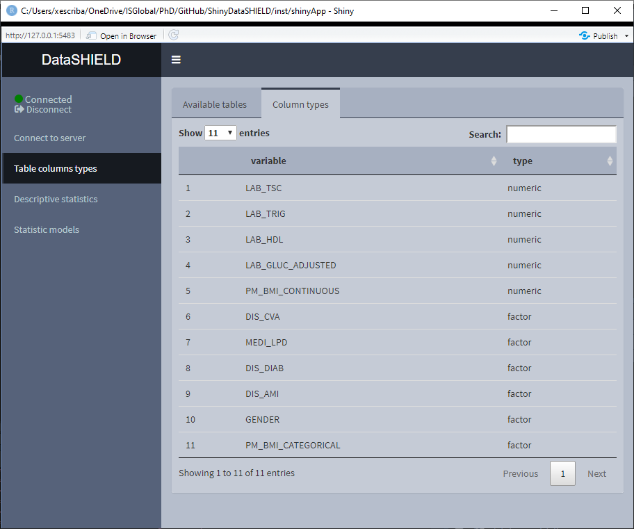

Figure 3.15: Classes of the CNSIM table

Aside from that, there’s the option of changing the class of a column. This transformation is done using the proper DataSHIELD functions that perform disclosive checks before allowing the transformation. This is specially important for transformation from numeric to factor for example.

The allowed classes to perform transformations are:

- Character
- Numeric
- Factor

To perform a class change, double click on the desired row and and a drop-down menu will appear, choose the new class and click ‘Confirm,’ after the checks, the table will be updated to display the new class.

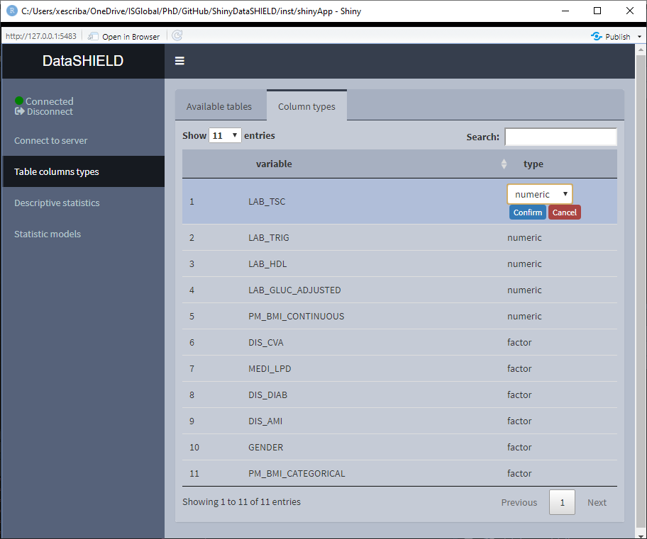

Figure 3.16: Class change

Integer could be added if it was of interest. Please [file an issue on GitHub](https://github.com/isglobal-brge/ShinyDataSHIELD/issues) if that is the case.

## 3.3 Descriptive statistics

| ⚠️ TABLES USED TO DEMO THIS SECTION |
| --- |
| From https://opal-demo.obiba.org/ : |
| STUDY TABLE PROFILE Study1a CNSIM.CNSIM1 default Study1b CNSIM.CNSIM2 default Study1c CNSIM.CNSIM3 default |

The descriptive statistics functionality is available for tables as well as the following resource types:

- SQL tables
- Tidy data files (tables): `*.csv`, `*.tsv`, etc

All of the above options will be shown on the table that shows the available tables to use on this module. As stated on the use cases, to perform a pooled analysis the tables have to be on different study servers. Column integrity is checked before allowing the user the access to the other tabs.

When using pooled data the descriptive statistics is by default of the pooled data, however, the graphical visualizations included on descriptive statistics provide the option of showing separated plots for the different studies.

### 3.3.1 Summary

The summary provides non-disclosive insights on the different variables of the loaded data. This functionality is only available for factors and numeric variables, only variables that meet this criteria will be on the selector. When the desired summary is disclosive no table will be shown (as the function call returns an Error stating that the the return is disclosive).

When the selected variable is a factor, the output shown is a count of all the different factors. It can be visualized with the pooled data or divided by study servers.

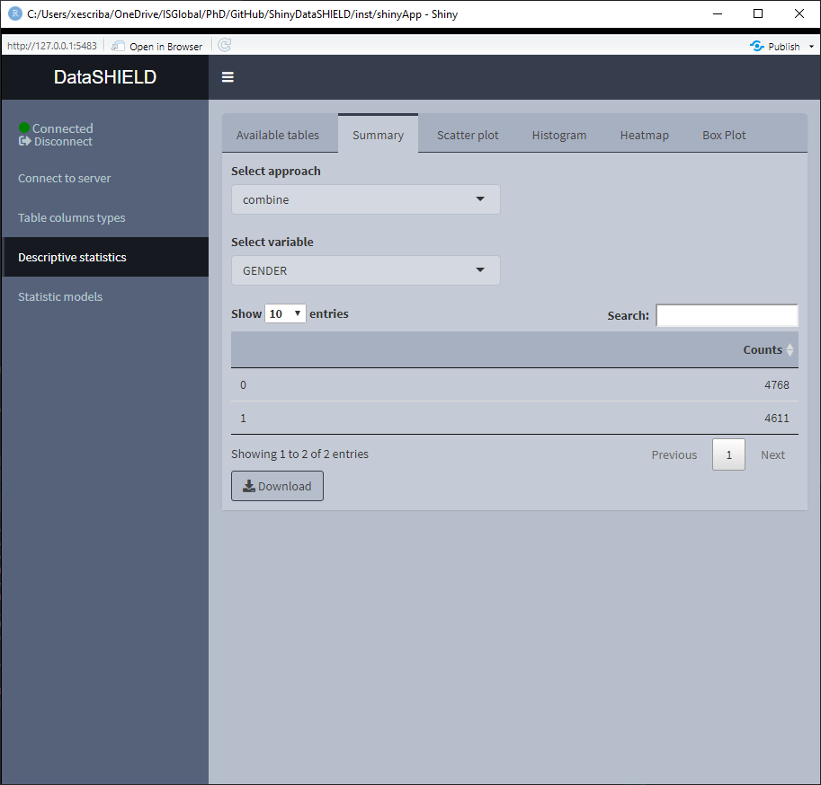

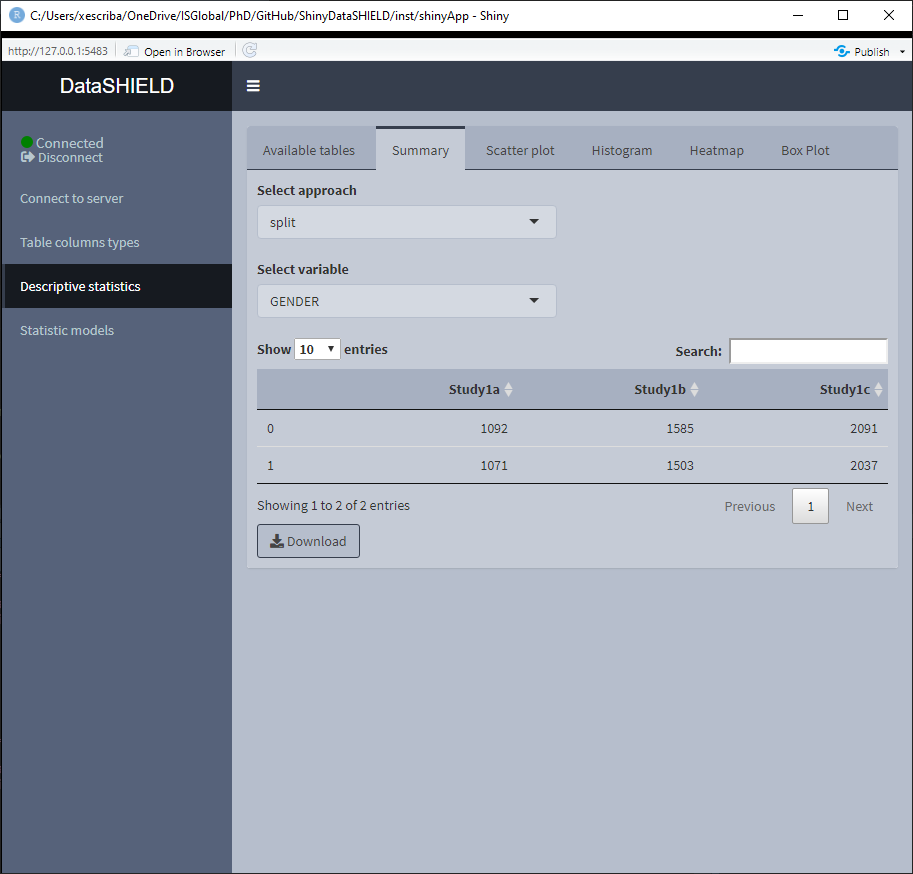

When the selected variable is numerical, the output shown is a quantiles and mean table. It can be visualized with the pooled data or divided by study servers.

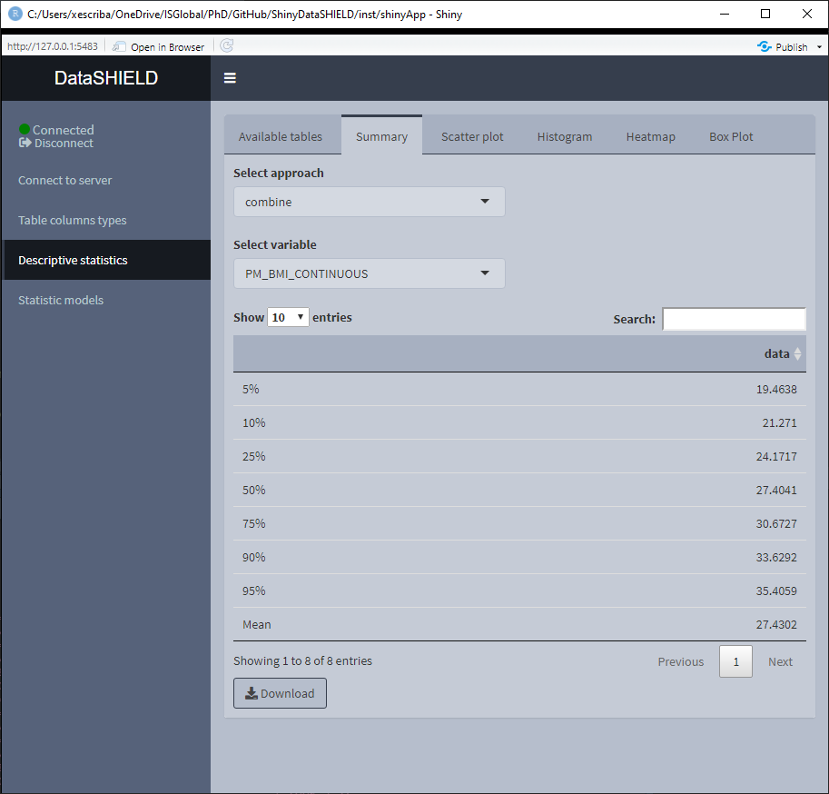

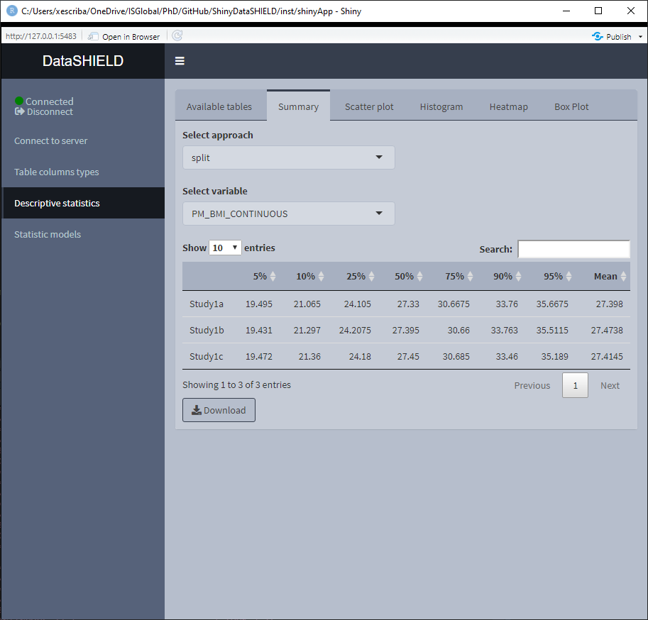

### 3.3.2 Scatter plot

Create a non-disclosive scatter plot by selecting two numerical variables (one for each axis). This type of plot can only be generated using numerical variables, for that reason variables that do not meet this criteria are not shown on the selector. It can be visualized with the pooled data or divided by study servers.

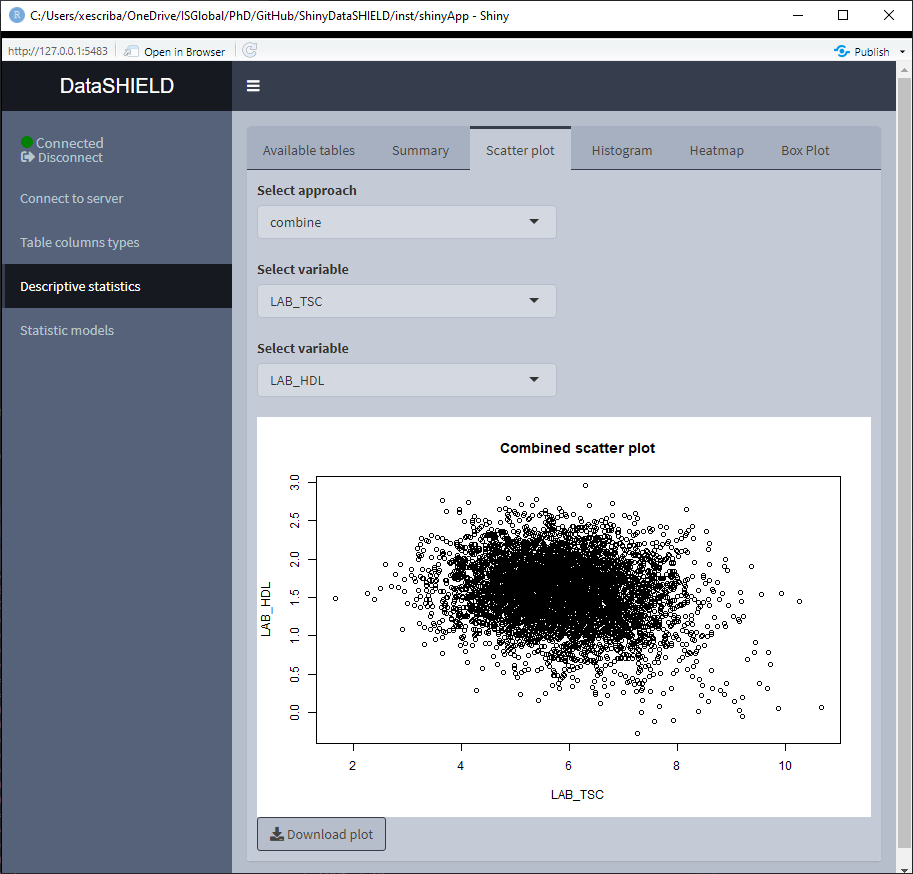

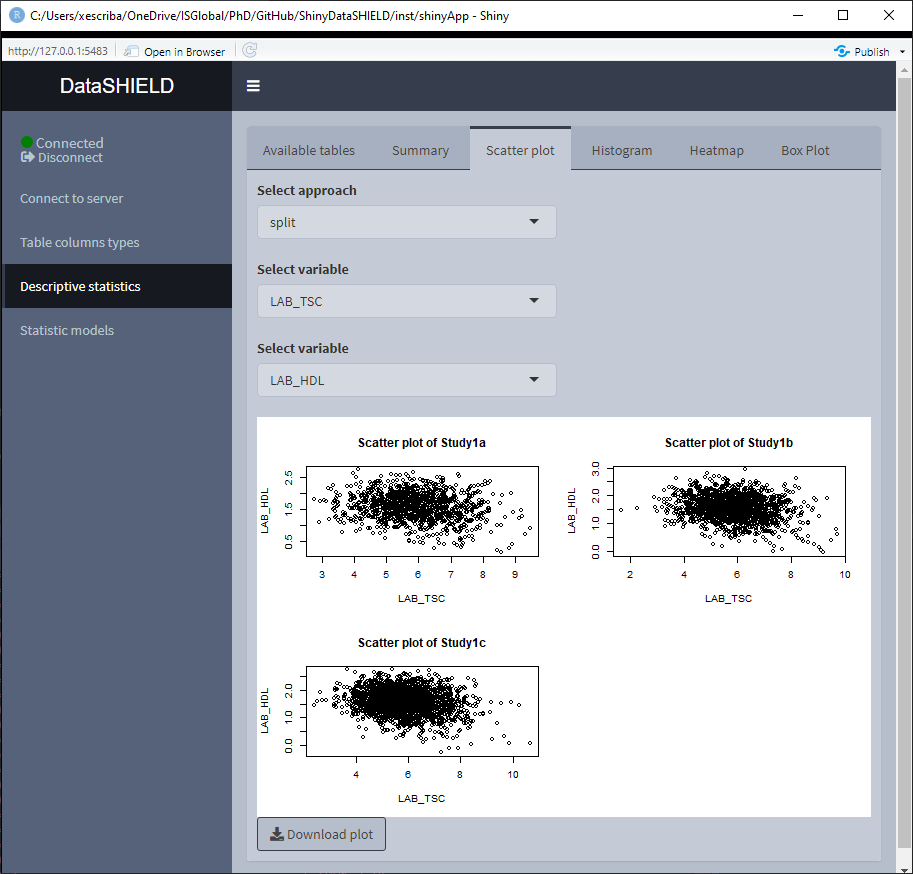

### 3.3.3 Histogram

Create a non-disclosive histogram of a selected variable. This type of plot can only be generated using numerical variables, for that reason variables that do not meet this criteria are not shown on the selector. It can be visualized with the pooled data or divided by study servers.

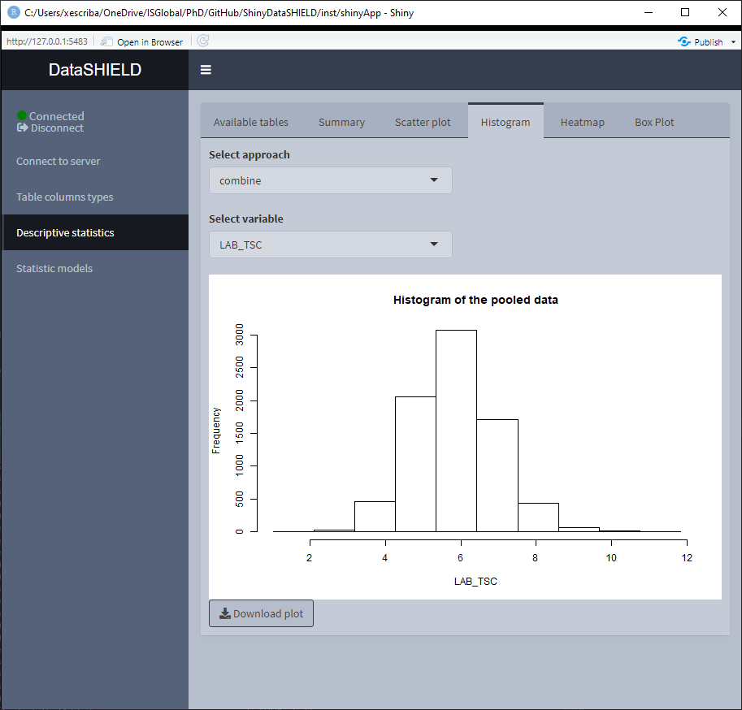

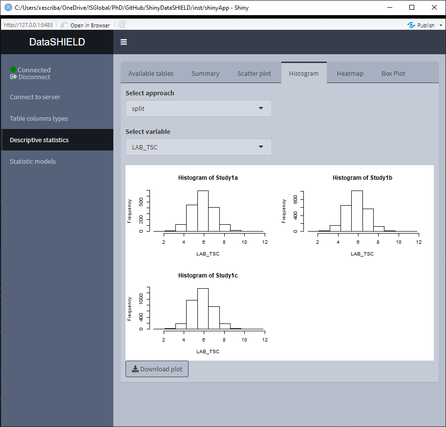

### 3.3.4 Heatmap

Create a non-disclosive heatmap plot by selecting two numerical variables (one for each axis). This type of plot can only be generated using numerical variables, for that reason variables that do not meet this criteria are not shown on the selector. It can be visualized with the pooled data or divided by study servers.

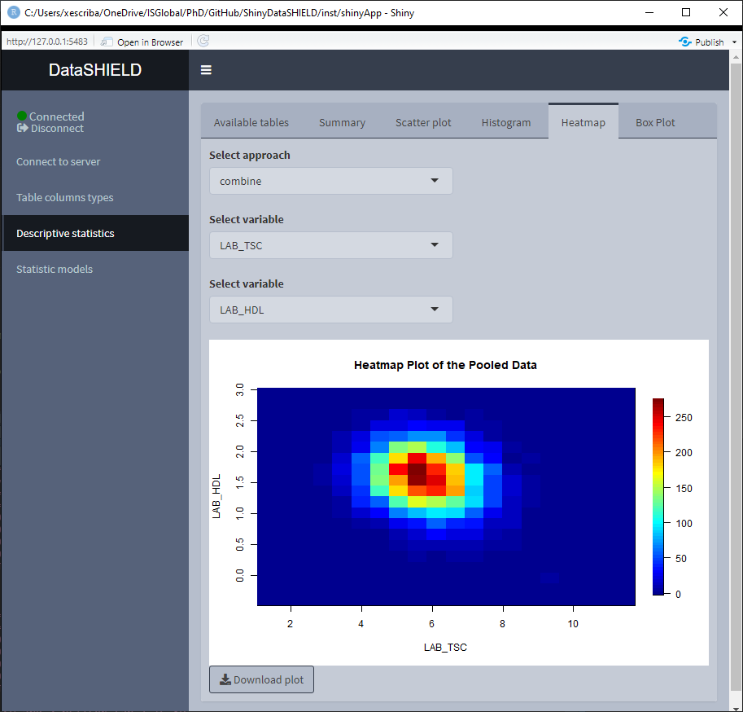

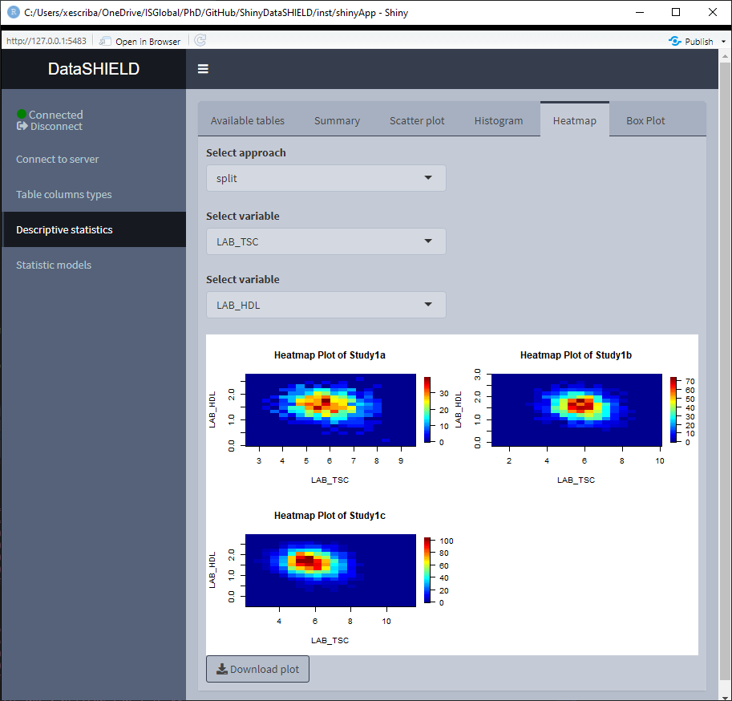

### 3.3.5 Boxplot

Create a non-disclosive Boxplot by selecting as many numerical variables as desired. This plot has the option of performing groupings using one or two factor variables from the same table. It can be visualized with the pooled data or divided by study servers.

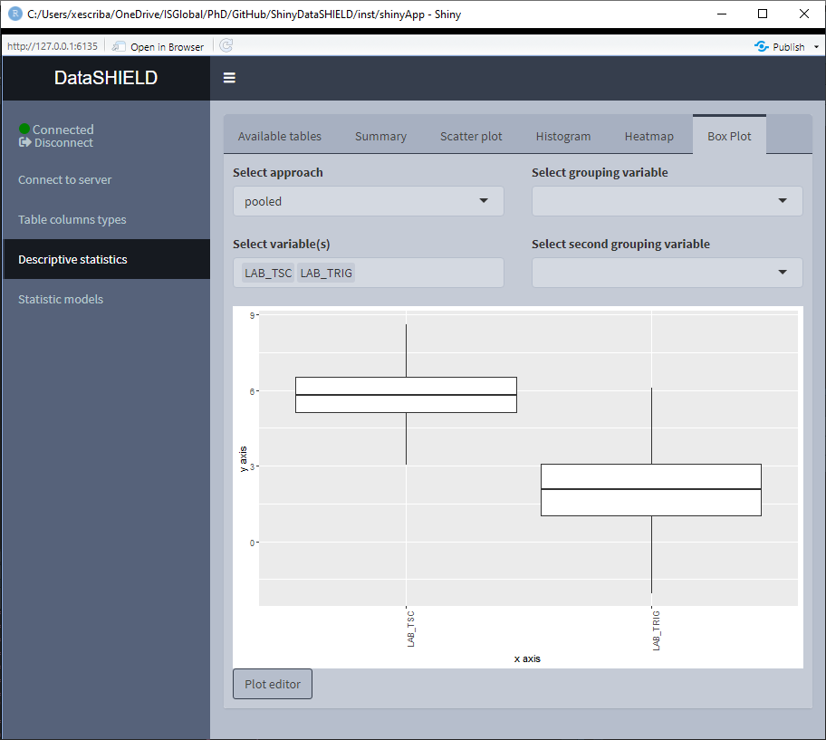

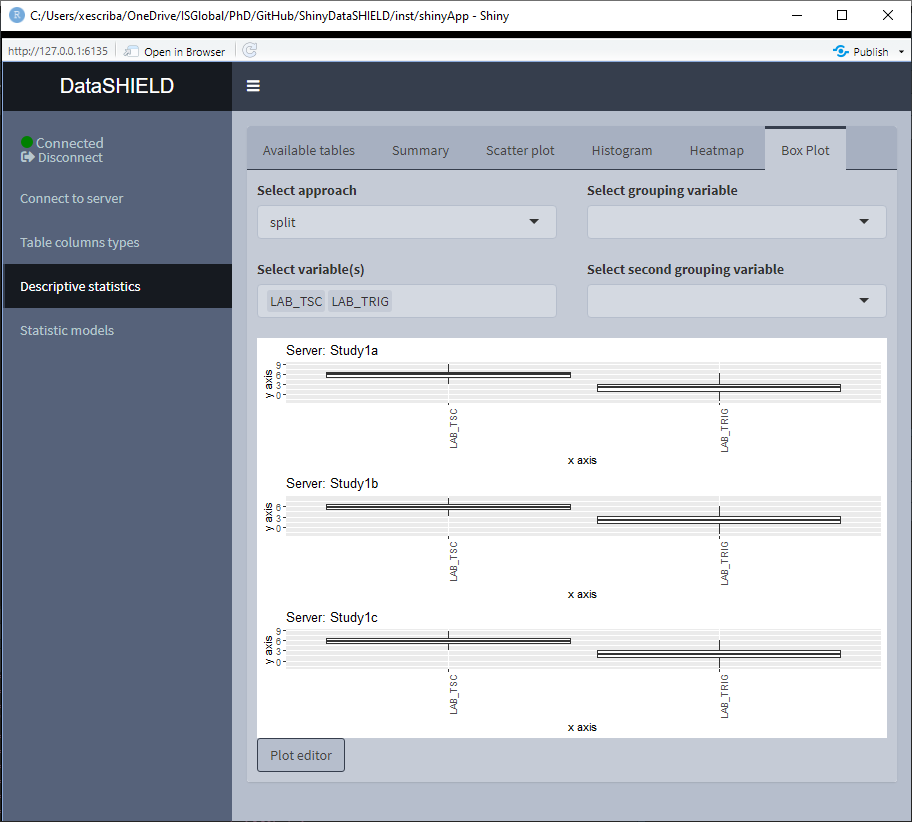

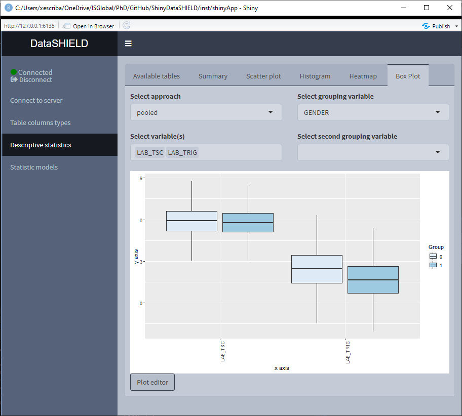

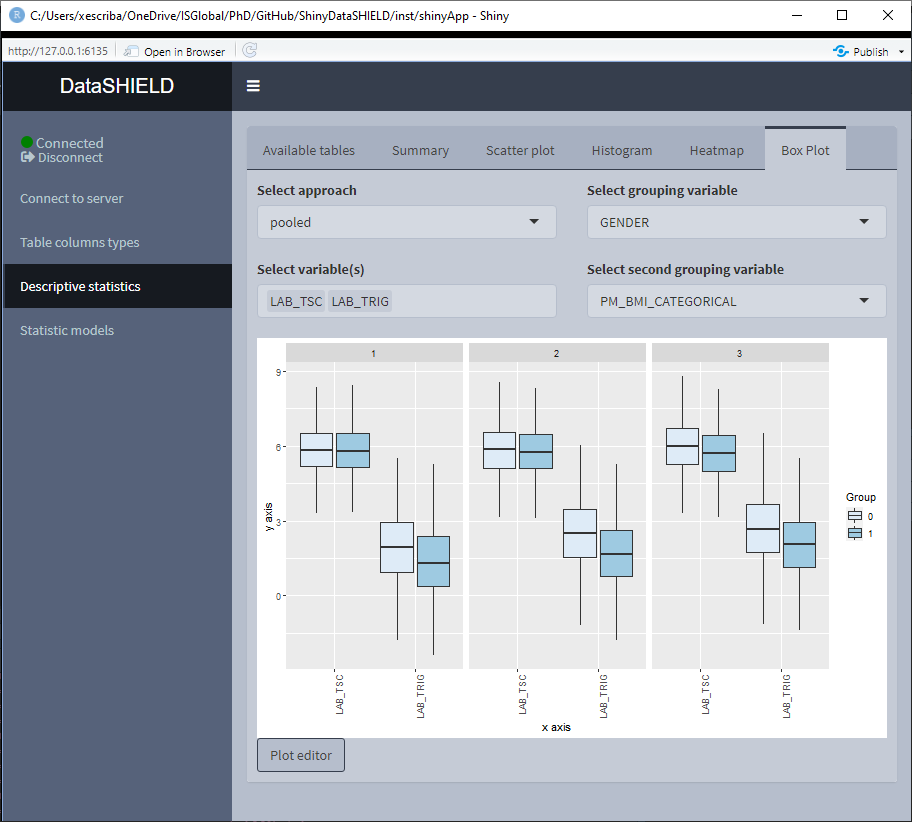

The Boxplot functionality uses `ggplot2`; a novel in-app editor named `ggEditLite` has been introduced inside the Shiny application to allow simple graphic modifications of the plot to adapt it to the style of choice, add title, subtitle, etc. This feature will be rolled out to all the plots as they get upgraded to make use of the `ggplot2` package.

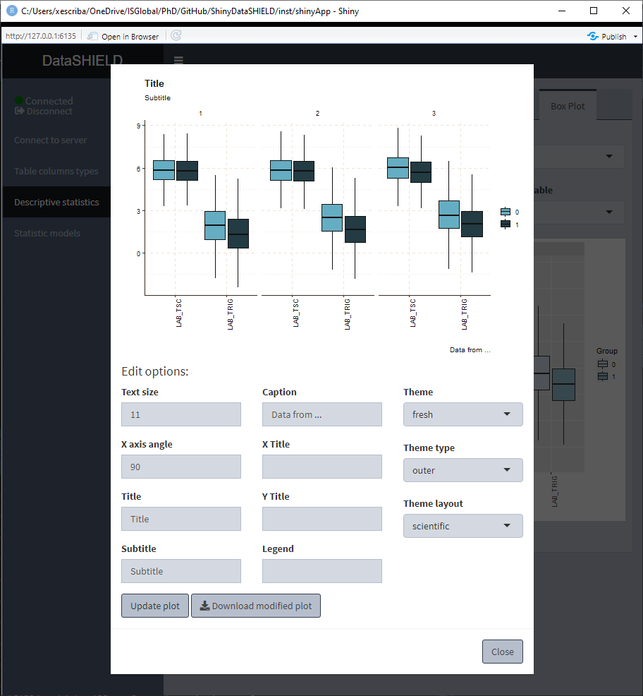